# Climate-change-with-matplotlib

```python
import matplotlib as mpl
import matplotlib.pyplot as plt
import pandas as pd
!pip install xlrd
```

[figure not shown]

ClIMATE CHANGE

Climate Change and Global Warming:

The term “Climate change” includes global warming,but refers to the broader range of changes in Earth's climate system that result in new weather patterns that last for at least a few decades, and maybe for millions of years. “Global warming” refers to the long-term warming of the planet which most scientists agree is largely caused by human activity.

Main Cause for Global Warming:

Source: https://www.epa.gov/ghgemissions/global-greenhouse-gas-emissions-data

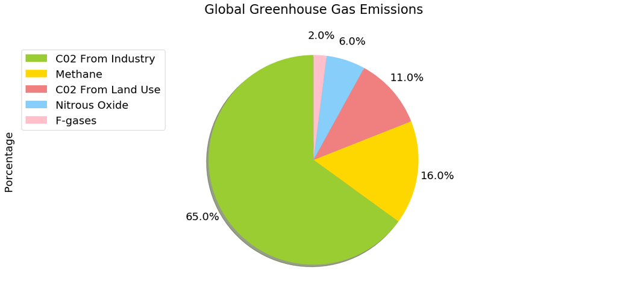

```python
#Global Greenhouse gasses plot.
data = [['C02 From Industry', 65], ['Methane', 16], ['C02 From Land Use', 11], ['Nitrous Oxide', 6],['F-gases', 2]]
colors_list = ['yellowgreen','gold', 'lightcoral', 'lightskyblue', 'pink']

df = pd.DataFrame(data, columns = ['Greenhouse Gas', 'Porcentage'])

df['Porcentage'].plot(kind='pie',
                        figsize=(20, 8),
                        autopct='%1.1f%%',
                        startangle=90,
                        shadow=True,
                        labels=None,
                        pctdistance=1.19,
                        colors=colors_list)


plt.title('Global Greenhouse Gas Emissions', y=1.12)
plt.axis('equal')
plt.legend(labels=df['Greenhouse Gas'], loc='upper left')
plt.rc('font', size=20)

plt.show()
```

Source: https://www.climateinteractive.org/programs/scoreboard/scoreboard-science-and-data/

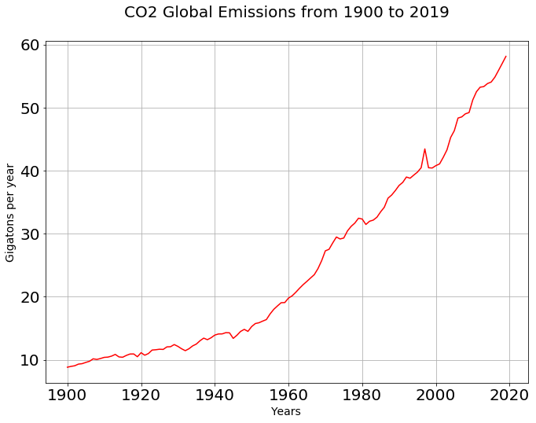

```python
#CO2 Global Emissions from 1900 to 2019 plot
FILE = 'global_CO2_emissions.txt'

with open(FILE, 'r') as fdin:
    list_of_data1 = [line.strip() for  line in fdin]

list_of_data2 = [float(data) for data in list_of_data1]
years = range(1900, 2020)

data_dictionary = dict(zip(years, list_of_data2))
x = list(data_dictionary.keys())
y = list(data_dictionary.values())

plt.plot(x, y, "r")
plt.title('CO2 Global Emissions from 1900 to 2019', fontsize=20, pad=30)
plt.xlabel('Years', fontsize=14)
plt.ylabel('Gigatons per year', fontsize=14)
plt.grid(True)
plt.rcParams['figure.figsize'] = [11, 8]

plt.show()
```

Global surface temperature levels from 1880 to 2018:

Source: https://climate.nasa.gov/vital-signs/global-temperature/

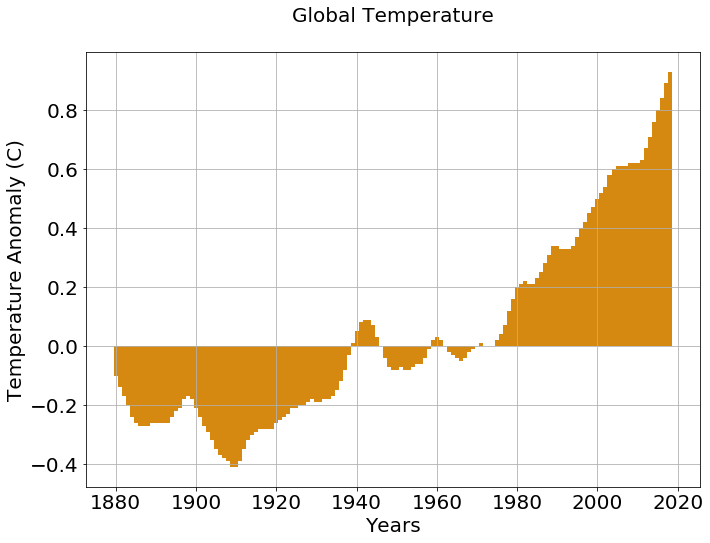

```python
#Global Temperature from 1880 to 2018 plot.

FILE = 'global_temperature.txt'

with open(FILE, 'r') as fdin:
     list_of_data1 = [line.strip() for  line in fdin]

list_of_data2 = [float(data) for data in list_of_data1]
years = range(1880, 2019)

data_dictionary = dict(zip(years, list_of_data2))
x = list(data_dictionary.keys())
y = list(data_dictionary.values())

plt.bar(x, y, width=1, color="#D68910")
plt.xlabel("Years")
plt.ylabel("Temperature Anomaly (C)")
plt.title('Global Temperature', fontsize=20, pad=30)
plt.grid(True)

plt.show()
```

Individual Solutions to Global Warming:

- Use energy wisely:
  - Wash clothes in cold or warm (not hot) water.
  - Unplug electronics when you’re not using them.
  - Change to energy-efficient light bulbs.
- Recycle - Reduce - Reuse.
- Eat for a climate-stable planet:
  - Eat meat-free meals.
  - Don't waste food or water.
- Spread the word.

References:

- [Matplotlib](https://matplotlib.org/)
- Intro picture from: [Climate 365](http://climate365.tumblr.com/)
- NASA's website on climate change: [NASA: Climate Change, How do we know?](https://climate.nasa.gov/evidence/) and: [NASA: Responding To Climate Change.](https://climate.nasa.gov/solutions/adaptation-mitigation/)
- Pie Chart data from: [EPA: Global Greenhouse Gas Emissions Data.](https://www.epa.gov/ghgemissions/global-greenhouse-gas-emissions-data)
- Line Plot data from: [Climate Interactive: Scoreboard Science and Data.](https://www.climateinteractive.org/programs/scoreboard/scoreboard-science-and-data/)
- Bar Chart data from: [NASA: Vital Signs Of The Planet - Temperature.](https://climate.nasa.gov/vital-signs/global-temperature/)
- [Individual Solutions To Global Warming.](https://davidsuzuki.org/what-you-can-do/top-10-ways-can-stop-climate-change/)
- [Nextflix Documentary: Our Planet.](https://www.netflix.com/title/80049832)
- [Greta Thunberg on Climate Change.](https://www.youtube.com/watch?v=H2QxFM9y0tY)